# HW2

# 6. Create a density plot of the random effects from your final model.

```r
# FOR CONCON
# random intercept
CONCON_re.sim_intercept= REsim(Random_intercept_only)
head(CONCON_re.sim_intercept)
```

```
##   groupFctr groupID        term        mean      median         sd
## 1        ID    L029 (Intercept) -0.02665888 -0.02709311 0.02859759
## 2        ID    L032 (Intercept) -0.04689010 -0.04648616 0.02930828
## 3        ID    L041 (Intercept)  0.04968411  0.05121955 0.02988881
## 4        ID    L043 (Intercept)  0.03134791  0.03076794 0.03760532
## 5        ID    L047 (Intercept)  0.01975392  0.01858679 0.03125199
## 6        ID    L053 (Intercept)  0.03812147  0.03783377 0.03251949
```

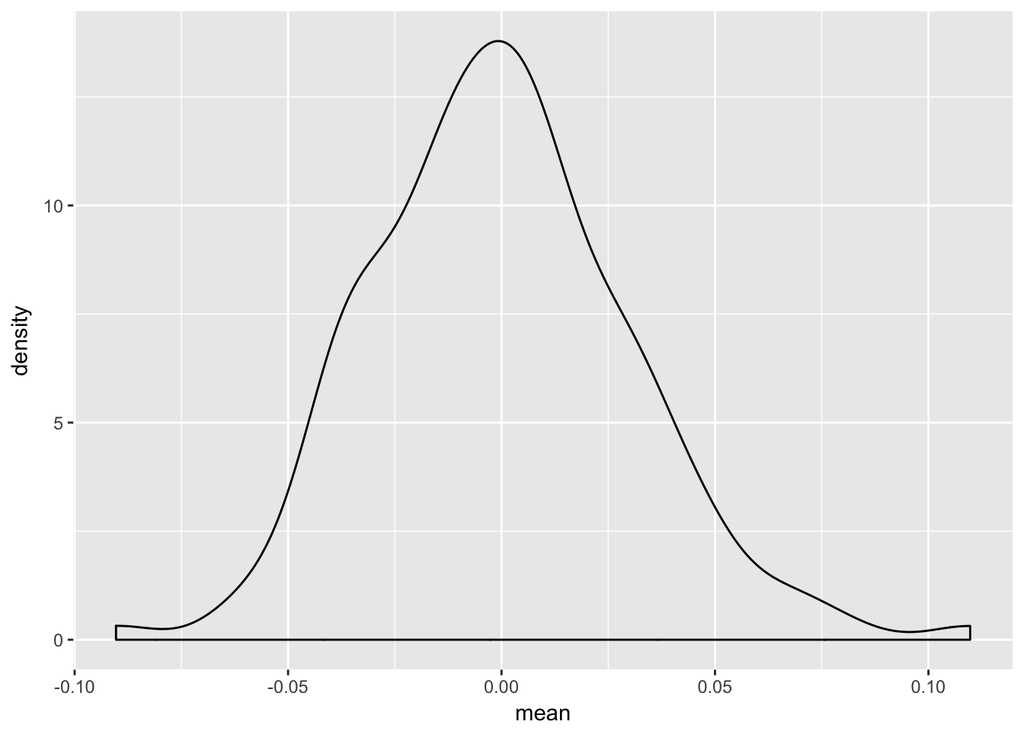

```r
CONCON_density= CONCON_re.sim_intercept %>%
  filter(term == "(Intercept)")
ggplot(CONCON_density, aes(mean)) + geom_density()
```

```r
# random slope
CONCON_re.sim_slope= REsim(randomslope1)
head(CONCON_re.sim_slope)
```

```
##   groupFctr groupID        term        mean      median         sd
## 1        ID    L029 (Intercept) -0.02909185 -0.02944760 0.03030881
## 2        ID    L032 (Intercept) -0.03230871 -0.03002793 0.03945269
## 3        ID    L041 (Intercept)  0.04872106  0.04769022 0.03001762
## 4        ID    L043 (Intercept)  0.03556126  0.03756773 0.03204319
## 5        ID    L047 (Intercept)  0.02051880  0.01892149 0.02793241
## 6        ID    L053 (Intercept)  0.03516640  0.03559832 0.03062330
```

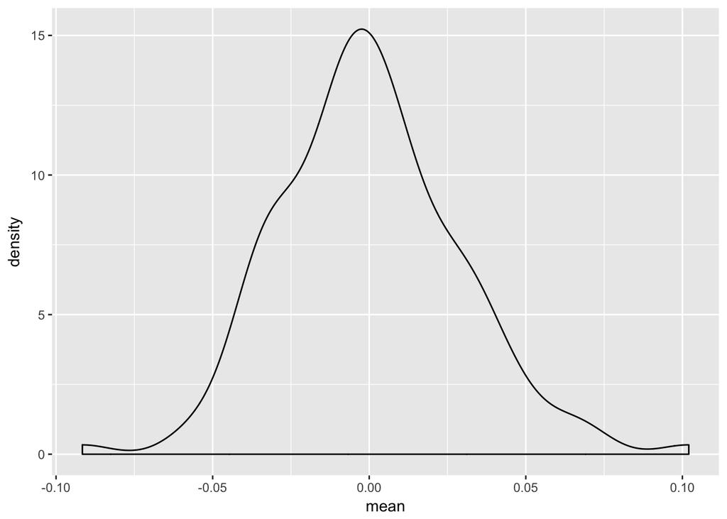

```r
CONCON_density2= CONCON_re.sim_slope %>%
  filter(term == "(Intercept)")
ggplot(CONCON_density2, aes(mean)) + geom_density()
```

```r
#FOR CONFPN

CONFPN_re.sim_intercept= REsim(model2)
head(CONFPN_re.sim_intercept)
```

```
##   groupFctr groupID        term         mean      median         sd
## 1        ID    L029 (Intercept)  0.025665958  0.02568840 0.01705353
## 2        ID    L032 (Intercept)  0.037638788  0.03752822 0.01846514
## 3        ID    L041 (Intercept) -0.029912390 -0.03071399 0.01710977
## 4        ID    L043 (Intercept) -0.001682083 -0.00143011 0.01994755
## 5        ID    L047 (Intercept) -0.021677372 -0.02170749 0.02029791
## 6        ID    L053 (Intercept)  0.025095427  0.02485064 0.01987541
```

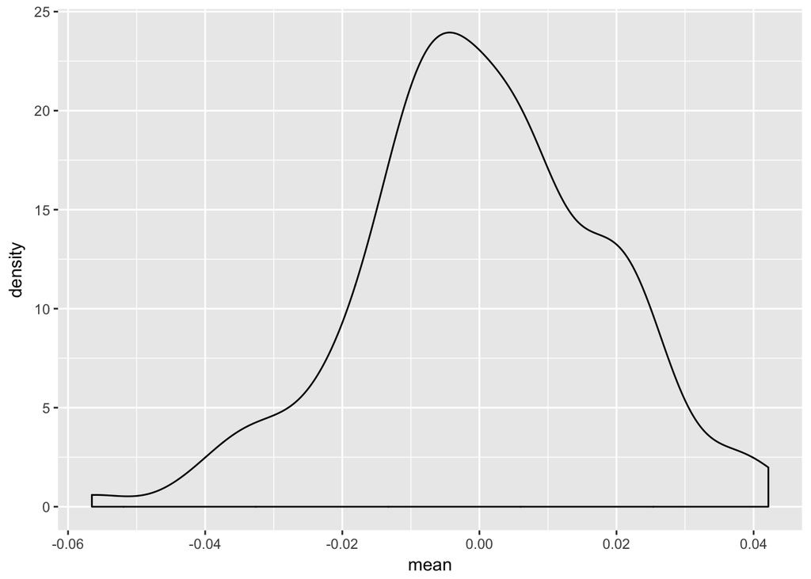

```r
CONFPN_density= CONFPN_re.sim_intercept %>%
  filter(term == "(Intercept)")
ggplot(CONFPN_density, aes(mean)) + geom_density()
```

```r
# random slope
CONFPN_re.sim_slope= REsim(randomslope2)
head(CONFPN_re.sim_slope)
```

```
##   groupFctr groupID        term          mean        median         sd
## 1        ID    L029 (Intercept)  0.0245455610  0.0246166839 0.01580511
## 2        ID    L032 (Intercept)  0.0201095588  0.0198469600 0.01845792
## 3        ID    L041 (Intercept) -0.0235104125 -0.0255583761 0.01773448
## 4        ID    L043 (Intercept) -0.0009357188 -0.0003338066 0.01814898
## 5        ID    L047 (Intercept) -0.0134816561 -0.0128649848 0.01891728
## 6        ID    L053 (Intercept)  0.0184039287  0.0198821354 0.02093981
```

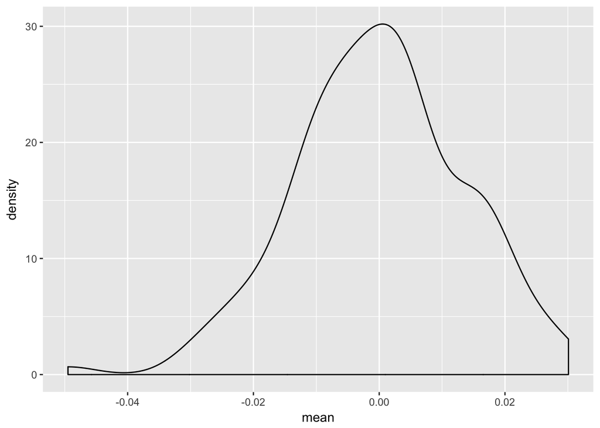

```r
CONFPN_density2= CONFPN_re.sim_slope %>%
  filter(term == "(Intercept)")
ggplot(CONFPN_density2, aes(mean)) + geom_density()
```

# 7. Create a catepilar plot of the random effects.

Is there any person that seems odd in terms of a large standard errors around intercept and slope estimates?

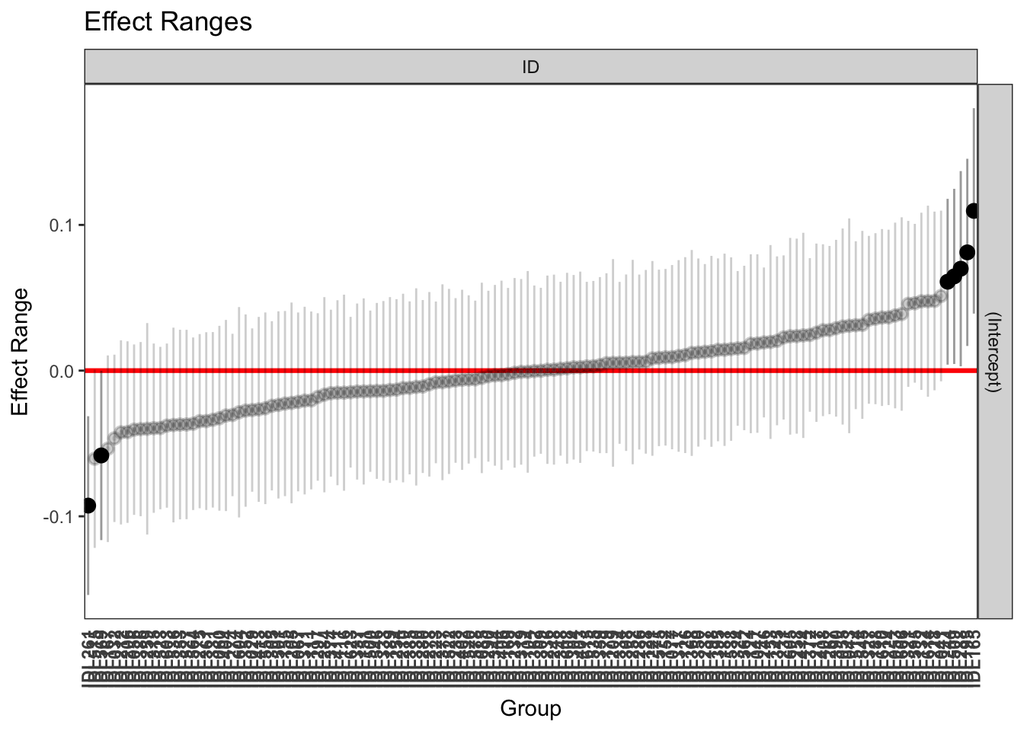

```r
# FOR CONCON
p1= plotREsim(CONCON_re.sim_intercept, labs=T)
p1
```

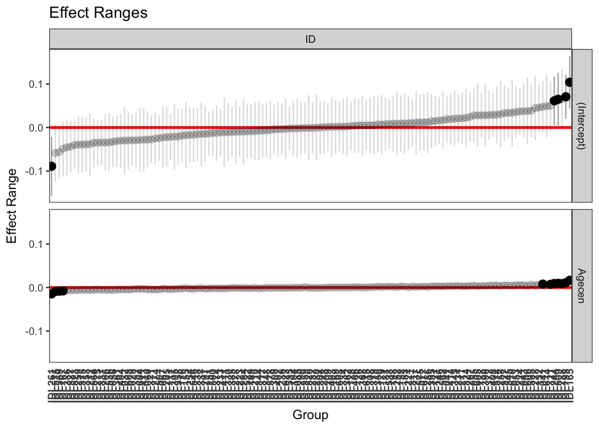

```r
q1=plotREsim(CONCON_re.sim_slope, labs = T)
q1
```

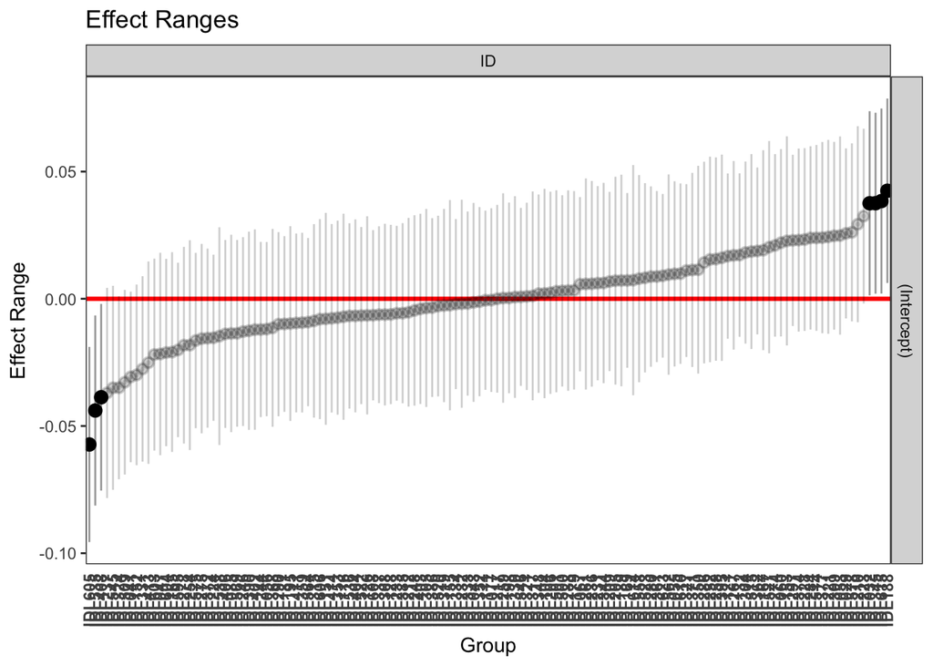

```r
## subjects 261 and 165 seems to have particularly large standard error around both the intercepts and slopes


#FOR CONFPN
p2= plotREsim(CONFPN_re.sim_intercept, labs = T)
p2
```

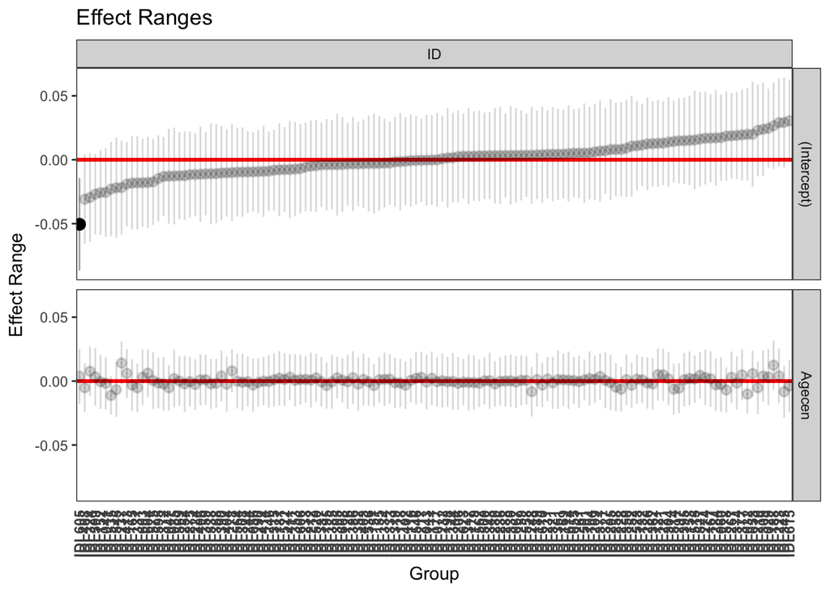

```r
q2=plotREsim(CONFPN_re.sim_slope, labs = T)
q2
```

```r
## subjects 605 has larger standard error around both the intercept.
```

# 8. Create a plot of the trajectory, along with a spaghetti plot of each person’s individual slope. Set the alpha level (transparency) on the individual slopes to make them easier to see.

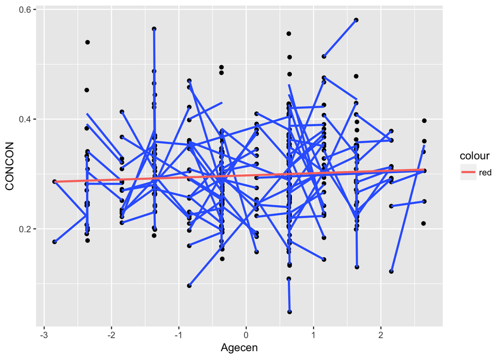

```r
# For CONCON

Plot= ggplot(wide_to_long_new, aes(x= Agecen, y= CONCON, group=ID)) +geom_point() +stat_smooth(method = "lm", se= FALSE)
Plot2= Plot + stat_smooth(data= wide_to_long_new, aes (x=Agecen, y= CONCON, group=1, colour="red"), method="lm", se=FALSE)
Plot2
```

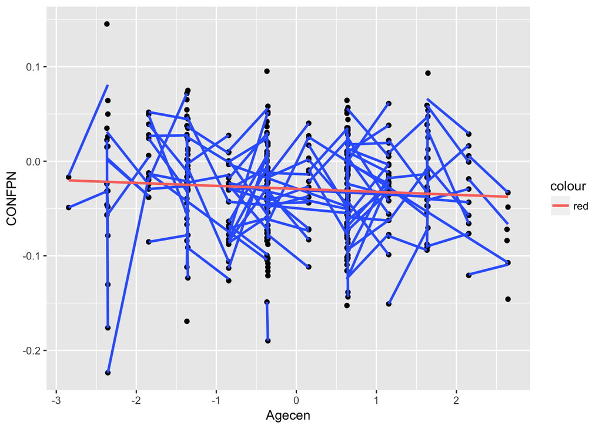

```r
# For CONFPN

Plot1= ggplot(wide_to_long_new, aes(x= Agecen, y= CONFPN, group=ID)) +geom_point() +stat_smooth(method = "lm", se= FALSE)
Plot3= Plot1 + stat_smooth(data= wide_to_long_new, aes (x=Agecen, y= CONFPN, group=1, colour="red"), method="lm", se=FALSE)
Plot3
```